# Exercícios - Aula 1 (11 e 18/08)

Diego Galdino França

22/08/2021

O arquivo `Rmarkdown` que gerou este documento pode ser encontrado [aqui](https://github.com/diegogaldinof/disciplina-psicometria/blob/master/Aula%201%20-%20Introducao%20a%20psicometria/exercicios.Rmd).

## Exercício 1

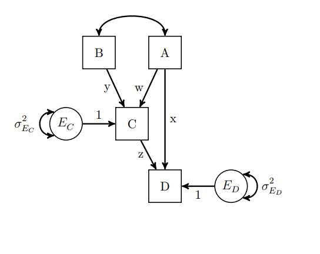

#### Expressar o modelo de trajetória representado na figura acima usando a sintaxe do pacote `lavaan` do R.

**Modelo**

```r
modelo <- "C ~ w*A + y*B
           D ~ z*C + x*A
           B ~~ A
           yz := y*z
           wz := w*z
           Total := x + yz + wz"
```

**Prova**

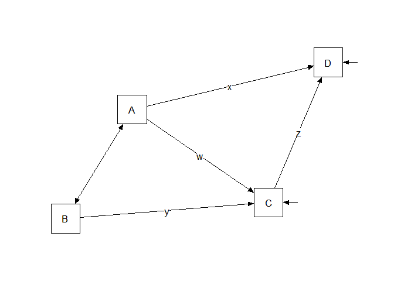

```r
# dummy data
nomes <- c("A", "B", "C", "D")

df <- data.frame(rnorm(500),
                 rnorm(500),
                 rnorm(500),
                 rnorm(500))
covar <- cov(df)
rownames(covar) <- colnames(covar) <- nomes

# SEM
mod <- sem(modelo, sample.cov = covar, sample.nobs = 500)
semPlot::semPaths(mod, layout = "spring",
    style = "lisrel", what = "path",
    whatLabels = "path", rotation = 1,
    edge.color = "black", edge.label.cex = 1.25,
    nCharNodes = 3, sizeMan = 8,
    sizeInt = 4)
```

## Exercício 2

#### 2.1 Input the covariances into R.

```r
nomes <- c("TeacherExpectances", "SocialClimate",
           "MaterialCovered", "StudentAchievement")
dados <- c(84.85,
           71.28, 140.34,
           18.83, -6.25, 72.92,
           60.05, 84.54, 37.18, 139.48)

covar <- getCov(dados, names = nomes)
```

|  | TE | SC | MC | SA |
| --- | --- | --- | --- | --- |
| Teacher Expectances | 84.85 | 71.28 | 18.83 | 60.05 |
| Social Climate | 71.28 | 140.34 | -6.25 | 84.54 |
| Material Covered | 18.83 | -6.25 | 72.92 | 37.18 |
| Student Achievement | 60.05 | 84.54 | 37.18 | 139.48 |

#### 2.2 Write the sintax for the model.

**Modelo**

```r
modelo <- "MaterialCovered ~ a2 * TeacherExpectances
           StudentAchievement ~ b1 * SocialClimate + b2 * MaterialCovered + c * TeacherExpectances
           SocialClimate ~ a1 * TeacherExpectances
           # Indirect effects
           a1b1 := a1 * b1
           a2b2 := a2 * b2
           Total := (a1*b1) + (a2*b2) + c"
```

**Prova**

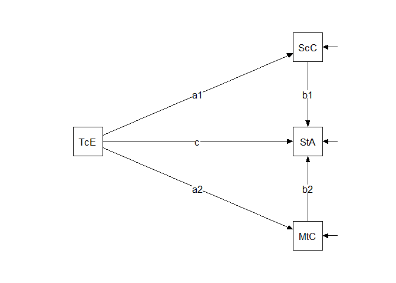

```r
mod <- sem(modelo, sample.cov = covar, sample.nobs = 40)
semPlot::semPaths(mod, layout = "tree",
    style = "lisrel", what = "path",
    whatLabels = "path", rotation = 2,
    edge.color = "black", edge.label.cex = 1.25,
    nCharNodes = 3, sizeMan = 8,
    sizeInt = 4)
```

#### 2.3 What are the indirect effects?

**Modelo**

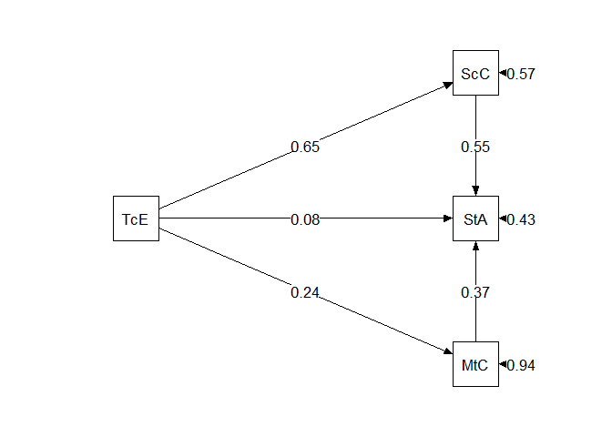

```r
semPlot::semPaths(mod, layout = "tree",
    style = "lisrel", what = "path",
    whatLabels = "std", rotation = 2,
    edge.color = "black", edge.label.cex = 1.25,
    nCharNodes = 3, sizeMan = 8,
    sizeInt = 4)
```

**Output**

```r
summary(mod, std = TRUE, fit = TRUE, rsq = TRUE)
```

```
## lavaan 0.6-8 ended normally after 17 iterations
##
##   Estimator                                         ML
##   Optimization method                           NLMINB
##   Number of model parameters                         8
##
##   Number of observations                            40
##
## Model Test User Model:
##
##   Test statistic                                 3.687
##   Degrees of freedom                                 1
##   P-value (Chi-square)                           0.055
##
## Model Test Baseline Model:
##
##   Test statistic                                58.874
##   Degrees of freedom                                 6
##   P-value                                        0.000
##
## User Model versus Baseline Model:
##
##   Comparative Fit Index (CFI)                    0.949
##   Tucker-Lewis Index (TLI)                       0.695
##
## Loglikelihood and Information Criteria:
##
##   Loglikelihood user model (H0)               -424.587
##   Loglikelihood unrestricted model (H1)       -422.743
##
##   Akaike (AIC)                                 865.174
##   Bayesian (BIC)                               878.685
##   Sample-size adjusted Bayesian (BIC)          853.651
##
## Root Mean Square Error of Approximation:
##
##   RMSEA                                          0.259
##   90 Percent confidence interval - lower         0.000
##   90 Percent confidence interval - upper         0.564
##   P-value RMSEA <= 0.05                          0.067
```

[output cut: 24 more lines]

```
##    .MaterialCoverd   67.023   14.987    4.472    0.000   67.023    0.943
##    .StudentAchvmnt   63.323   14.159    4.472    0.000   63.323    0.425
##    .SocialClimate    78.448   17.542    4.472    0.000   78.448    0.573
##
## R-Square:
##                    Estimate
##     MaterialCoverd    0.057
##     StudentAchvmnt    0.575
##     SocialClimate     0.427
##
## Defined Parameters:
##                    Estimate  Std.Err  z-value  P(>|z|)   Std.lv  Std.all
##     a1b1              0.478    0.148    3.229    0.001    0.478    0.356
##     a2b2              0.118    0.083    1.421    0.155    0.118    0.088
##     Total             0.708    0.180    3.926    0.000    0.708    0.527
```

Pelo `lavaan`, podemos calcular o efeito indireto da variável *Teacher Expectances* subtraindo o efeito *Total* (última linha da saída), 0.527, do efeito direto entre *Teacher Expectances* e *Student Achievement* (aba *Regression*: StudentAchievement ~ TchrExpct (c)), 0.084.

$$0.527 - 0.084 = 0.443$$
Temos que o efeito indireto foi de 0.443. Usarei a função `psych::mediate` para testar o resultado.

**`psych::mediate`**

```r
mod2 <- mediate(y = "StudentAchievement",
             x = "TeacherExpectances",
             m = c("MaterialCovered", "SocialClimate"),
             std = TRUE, data = covar, n.obs = 40)
```

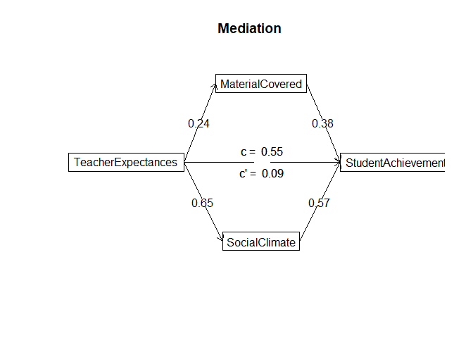

```
##
## Mediation/Moderation Analysis
## Call: mediate(y = "StudentAchievement", x = "TeacherExpectances", m = c("MaterialCovered",
##     "SocialClimate"), data = covar, n.obs = 40, std = TRUE)
##
## The DV (Y) was  StudentAchievement . The IV (X) was  TeacherExpectances . The mediating variable(s) =  MaterialCovered SocialClimate .
##
## Total effect(c) of  TeacherExpectances  on  StudentAchievement  =  0.55   S.E. =  0.14  t  =  4.08  df=  38   with p =  0.00022
## Direct effect (c') of  TeacherExpectances  on  StudentAchievement  removing  MaterialCovered SocialClimate  =  0.09   S.E. =  0.16  t  =  0.54  df=  36   with p =  0.59
## Indirect effect (ab) of  TeacherExpectances  on  StudentAchievement  through  MaterialCovered SocialClimate   =  0.46
## Mean bootstrapped indirect effect =  0.43  with standard error =  0.1  Lower CI =  0.22    Upper CI =  0.63
## R = 0.73 R2 = 0.53   F = 13.77 on 3 and 36 DF   p-value:  6.58e-07
##
##  To see the longer output, specify short = FALSE in the print statement or ask for the summary
```

Por sua vez, a função `psych::mediate` sugere que o efeito indireto foi de 0.46. Esse efeito também pode ser escrito em função do efeito *Total* (0.55) menos o efeito *Direto* (0.09) da variável *Teacher Expectances* sobre *Student Achievement*

## Exercício 3

#### 3.1 Enter the covariance matrix into R.

```r
nomes <- c("D1", "D2", "D3", "SA", "F",
           "CC", "PA", "PM")

v <- c(0.77,
       0.38, 0.65,
       0.39, 0.39, 0.62,
       -0.25, -0.32, -0.27, 6.09,
       0.31, 0.29, 0.26, -0.36, 7.67,
       0.24, 0.25, 0.19, -0.18, 0.51, 1.69,
       -3.16, -3.56, -2.63, 6.09, -3.12, -4.58, 204.79,
       -0.92, -0.88, -0.72, 0.88, -1.49, -1.41, 16.53, 7.24)

covar <- getCov(v, names = nomes)
kable(covar)
```

|  | D1 | D2 | D3 | SA | F | CC | PA | PM |
| --- | --- | --- | --- | --- | --- | --- | --- | --- |
| D1 | 0.77 | 0.38 | 0.39 | -0.25 | 0.31 | 0.24 | -3.16 | -0.92 |
| D2 | 0.38 | 0.65 | 0.39 | -0.32 | 0.29 | 0.25 | -3.56 | -0.88 |
| D3 | 0.39 | 0.39 | 0.62 | -0.27 | 0.26 | 0.19 | -2.63 | -0.72 |
| SA | -0.25 | -0.32 | -0.27 | 6.09 | -0.36 | -0.18 | 6.09 | 0.88 |
| F | 0.31 | 0.29 | 0.26 | -0.36 | 7.67 | 0.51 | -3.12 | -1.49 |
| CC | 0.24 | 0.25 | 0.19 | -0.18 | 0.51 | 1.69 | -4.58 | -1.41 |
| PA | -3.16 | -3.56 | -2.63 | 6.09 | -3.12 | -4.58 | 204.79 | 16.53 |
| PM | -0.92 | -0.88 | -0.72 | 0.88 | -1.49 | -1.41 | 16.53 | 7.24 |

#### 3.2 Fit the SEM model to the data.

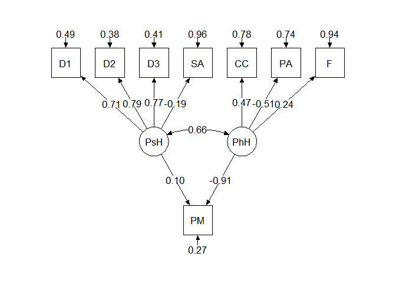

```r
modelo <- "PsychH =~ D1 + D2 + D3 + SA
           PhysicalH =~ CC + PA + F
           PM ~ PsychH + PhysicalH"

ex3 <- sem(modelo, sample.cov = covar, sample.nobs = 6053, std.lv = TRUE)
semPlot::semPaths(ex3, layout = "tree",
    style = "lisrel", what = "path",
    whatLabels = "std", rotation = 1,
    residuals = TRUE, edge.color = "black",
    edge.label.cex = 1.25, nCharNodes = 3,
    sizeMan = 8, sizeInt = 4)
```

#### 3.3 Are both psychosocial and physical health preditive of personal mobility?

```r
summary(ex3, std = TRUE, fit = TRUE, rsq = TRUE)
```

```
## lavaan 0.6-8 ended normally after 42 iterations
##
##   Estimator                                         ML
##   Optimization method                           NLMINB
##   Number of model parameters                        18
##
##   Number of observations                          6053
##
## Model Test User Model:
##
##   Test statistic                               254.865
##   Degrees of freedom                                18
##   P-value (Chi-square)                           0.000
##
## Model Test Baseline Model:
##
##   Test statistic                             10290.938
##   Degrees of freedom                                28
##   P-value                                        0.000
##
## User Model versus Baseline Model:
##
##   Comparative Fit Index (CFI)                    0.977
##   Tucker-Lewis Index (TLI)                       0.964
##
## Loglikelihood and Information Criteria:
##
##   Loglikelihood user model (H0)             -95467.244
##   Loglikelihood unrestricted model (H1)     -95339.812
##
##   Akaike (AIC)                              190970.488
##   Bayesian (BIC)                            191091.238
##   Sample-size adjusted Bayesian (BIC)       191034.038
##
## Root Mean Square Error of Approximation:
##
##   RMSEA                                          0.047
##   90 Percent confidence interval - lower         0.042
##   90 Percent confidence interval - upper         0.052
##   P-value RMSEA <= 0.05                          0.856
```

[output cut: 42 more lines]

```
##    .F                 7.241    0.134   54.019    0.000    7.241    0.944
##    .PM                1.990    0.239    8.318    0.000    1.990    0.275
##     PsychH            1.000                               1.000    1.000
##     PhysicalH         1.000                               1.000    1.000
##
## R-Square:
##                    Estimate
##     D1                0.506
##     D2                0.618
##     D3                0.595
##     SA                0.038
##     CC                0.220
##     PA                0.262
##     F                 0.056
##     PM                0.725
```

Sim. Podemos ver que tanto Poor Psychosocial Health (carga do fator = 0.101) e Poor Physical Health (carga do fator = -0.914) são preditores de Personal Mobility (p < 0.05). No entanto, as magnitudes e as direções são diferentes.

Enquanto que o aumento de 1 desvio-padrão na variável latente Poor Psychosocial Health aumenta, em média, 0.1 desvios-padrões do indicador Personal Mobility, o aumento de 1 desvio-padrão na variável latente Poor Physical Health diminui, em média, 0.91 desvios-padrões do indicador.